# CaseStudy02

David

2023-08-09

Link For YouTube Video: https://youtu.be/xgMDbEJLvAI

Initial Setup and Obtaining of the data.

```r
# Loading Data From S3 Objects Using the aws.s3 package
#install.packages("magrittr")
library(tidyverse)
library(aws.s3)
#Key to Access AWS
Sys.setenv("AWS_ACCESS_KEY_ID" = "AKIA24NJSHXQZNNQCJPX",
           "AWS_SECRET_ACCESS_KEY" = "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",
           "AWS_DEFAULT_REGION" = "us-east-2")

# Using aws.s3 to obtain the files within a buck
aws.s3::bucketlist()
```

```
##            Bucket             CreationDate
## 1           bivin 2023-07-27T23:59:16.000Z
## 2     ddsproject1 2023-07-27T23:58:06.000Z
## 3   ds6306.unit13 2023-03-25T16:53:08.000Z
## 4 testbucketbivin 2023-07-27T18:20:40.000Z
## 5  unit13breakout 2023-07-27T20:01:02.000Z
```

```r
aws.s3::get_bucket("ddsproject1")
```

```
## Bucket: ddsproject1
##
## $Contents
## Key:            Case2PredictionsClassifyEXAMPLE.csv
## LastModified:   2023-04-01T23:26:57.000Z
## ETag:           "bd1de75effe9449f7d49a4de5116205a"
## Size (B):       3012
## Owner:          244d58669cf167603091f3194f7e19dc964453ccdec5c5eb3645ee5152f563e4
## Storage class:  STANDARD
##
## $Contents
## Key:            Case2PredictionsRegressEXAMPLE.csv
## LastModified:   2023-04-01T23:26:56.000Z
## ETag:           "a0f1f01c30e2cd00488822ad3c9aa6fe"
## Size (B):       3187
## Owner:          244d58669cf167603091f3194f7e19dc964453ccdec5c5eb3645ee5152f563e4
## Storage class:  STANDARD
##
## $Contents
## Key:            CaseStudy2-data.csv
## LastModified:   2023-04-01T23:26:59.000Z
## ETag:           "d68dd080517407fb3a4f05d91fed27d7"
## Size (B):       138428
## Owner:          244d58669cf167603091f3194f7e19dc964453ccdec5c5eb3645ee5152f563e4
## Storage class:  STANDARD
##
## $Contents
## Key:            CaseStudy2CompSet No Attrition.csv
## LastModified:   2023-04-01T23:27:00.000Z
## ETag:           "6c9d92b8a6fc5fd805ff0a5d4dfddde0"
## Size (B):       47686
## Owner:          244d58669cf167603091f3194f7e19dc964453ccdec5c5eb3645ee5152f563e4
## Storage class:  STANDARD
##
## $Contents
## Key:            CaseStudy2CompSet No Salary.csv
## LastModified:   2023-04-03T01:43:23.000Z
## ETag:           "30f4c83e1ebb33b19fe6b44c377a1fbd"
## Size (B):       46614
## Owner:          244d58669cf167603091f3194f7e19dc964453ccdec5c5eb3645ee5152f563e4
## Storage class:  STANDARD
##
## $Contents
## Key:            CaseStudy2CompSet No Salary.xlsx
## LastModified:   2023-04-01T23:27:02.000Z
## ETag:           "bdcb211847739638a631f828a3278339"
## Size (B):       56381
## Owner:          244d58669cf167603091f3194f7e19dc964453ccdec5c5eb3645ee5152f563e4
## Storage class:  STANDARD
```

```r
# Read in CaseStudy2-data.csv
case = s3read_using(FUN = read.csv,
                    bucket = "ddsproject1",
                    object = "CaseStudy2-data.csv")

# Reading in the competition set for later use
caseComp = s3read_using(FUN = read.csv,
                    bucket = "ddsproject1",
                    object = "CaseStudy2CompSet No Attrition.csv")

# Adding a column for Attrition as a continuous variable. May or may not be useful down
# the road
case <- mutate(case, Attrition_Fac = ifelse(case$Attrition == "No", 0, 1))


# Adding a column for OverTime as a continuous variable. May or may not be useful down
#the road
case <- mutate(case, OverTimeCont = ifelse(case$OverTime == "No", 0, 1))

# OverTimeCont as Int instead of just number
case$OverTimeCont <- as.integer(case$OverTimeCont)
```

Getting counts of Attrition: Yes v No and a summary

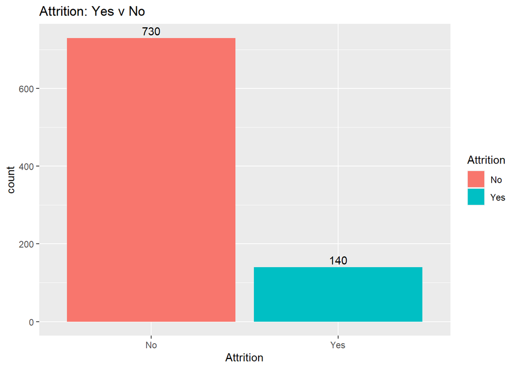

```r
case %>%
  ggplot(aes(x = Attrition, fill = Attrition)) +
  geom_bar() +
  ggtitle("Attrition: Yes v No") +
  geom_text(stat='count', aes(label=..count..), vjust= -.35)
```

```r
str(case)
```

```
## 'data.frame':    870 obs. of  38 variables:
##  $ ID                      : int  1 2 3 4 5 6 7 8 9 10 ...
##  $ Age                     : int  32 40 35 32 24 27 41 37 34 34 ...
##  $ Attrition               : chr  "No" "No" "No" "No" ...
##  $ BusinessTravel          : chr  "Travel_Rarely" "Travel_Rarely" "Travel_Frequently" "Travel_Rarely" ...
##  $ DailyRate               : int  117 1308 200 801 567 294 1283 309 1333 653 ...
##  $ Department              : chr  "Sales" "Research & Development" "Research & Development" "Sales" ...
##  $ DistanceFromHome        : int  13 14 18 1 2 10 5 10 10 10 ...
##  $ Education               : int  4 3 2 4 1 2 5 4 4 4 ...
##  $ EducationField          : chr  "Life Sciences" "Medical" "Life Sciences" "Marketing" ...
##  $ EmployeeCount           : int  1 1 1 1 1 1 1 1 1 1 ...
##  $ EmployeeNumber          : int  859 1128 1412 2016 1646 733 1448 1105 1055 1597 ...
##  $ EnvironmentSatisfaction : int  2 3 3 3 1 4 2 4 3 4 ...
##  $ Gender                  : chr  "Male" "Male" "Male" "Female" ...
##  $ HourlyRate              : int  73 44 60 48 32 32 90 88 87 92 ...
```

[output cut: 24 more lines]

Conducting an EDA and creating a scatter plot of the top contributing factors. Initial EDA was done in the Shiny App which allows the user to choose different x and y continuous variables. The app receives the variables and dynamically creates a scatter plot and smoothing line to show correlation. The shiny app significantly facilitated the EDA process. Below I draw a scatter plot of what looks to contain the top contributing factors for attrition.

My Shiny App can be found at: https://dicamacho.shinyapps.io/Attrition/

My logic for Age v NumCompaniesWorked is that if a young person has worked at multiple companies, they are more likely to turnover. My logic for YearsInCurrentRole v YearsSinceLastPromotion is that if a person has been in a role for quite a long time with little to no promotion, they are more likely to turnover

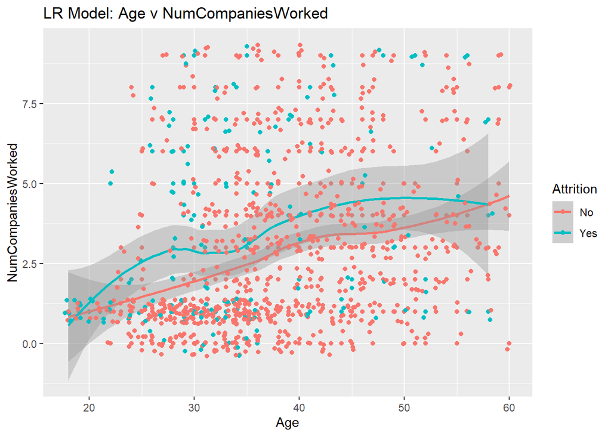

```r
# Looking for correlations among continuous variables that may show a strong
# relationship for attrition

# Scatter plot of Age v NumCompaniesWorked
#
case %>%
  ggplot(aes(x = Age, y = NumCompaniesWorked, color = Attrition)) +
  geom_point() +
  geom_smooth() +
  geom_jitter() +
  ggtitle("LR Model: Age v NumCompaniesWorked")
```

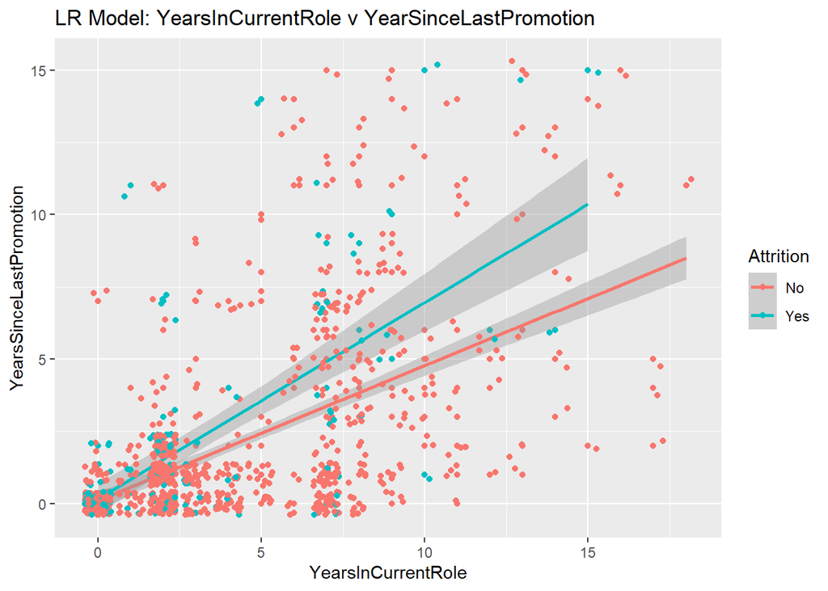

```r
case %>%
  ggplot(aes(x = YearsInCurrentRole, y = YearsSinceLastPromotion, color = Attrition)) +
  geom_point() +
  geom_smooth(method = "lm") +
  geom_jitter() +
  ggtitle("LR Model: YearsInCurrentRole v YearSinceLastPromotion")
```

Using KNN to Predict Attrition (Age~NumCompaniesWorked). The intent here is to obtain the most optimal k. I ran a for loop to store the mean accuracy for each iteration and used the max accuracy to determine the optimal k. Optimal Ks = 11 at .82 accuracy

```r
#install.packages("caret")
library(caret)
```

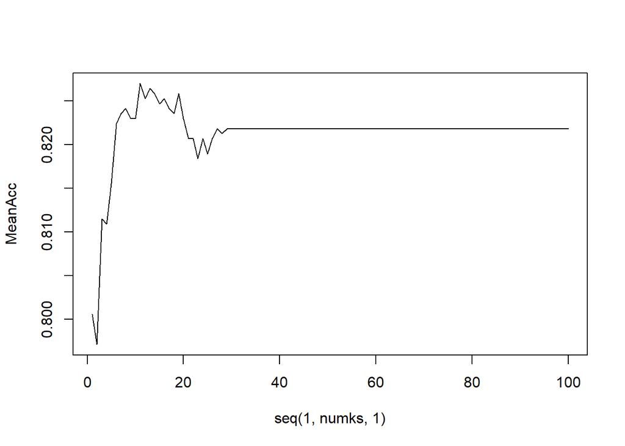

```r
library(class)

set.seed(1)
iterations = 10
numks = 100
splitPerc = .8

masterAcc = matrix(nrow = iterations, ncol = numks)

for(j in 1:iterations)
{
  trainIndices = sample(1:dim(case)[1],round(splitPerc * dim(case)[1]))
  train = case[trainIndices,]
  test = case[-trainIndices,]
  for(i in 1:numks)
  {
    classifications = knn(train[,c(2,22)],test[,c(2,22)],train$Attrition, prob = TRUE, k = i)
    table(classifications,test$Attrition)
    CM = confusionMatrix(table(classifications,test$Attrition))
    masterAcc[j,i] = CM$overall[1]
  }

}

MeanAcc = colMeans(masterAcc)

plot(seq(1,numks,1),MeanAcc, type = "l")
```

```r
which.max(MeanAcc)
```

```
## [1] 11
```

```r
max(MeanAcc)
```

```
## [1] 0.8270115
```

```r
#
trainIndices = sample(1:dim(case)[1],round(splitPerc * dim(case)[1]))
train = case[trainIndices,]
test = case[-trainIndices,]

classificationsK8 = knn(train[,c(2,22)],test[,c(2,22)],train$Attrition, prob = TRUE, k = 11)
confusionMatrix(table(classificationsK8, test$Attrition))
```

```
## Confusion Matrix and Statistics
##
##
## classificationsK8  No Yes
##               No  150  21
##               Yes   1   2
##
##                Accuracy : 0.8736
##                  95% CI : (0.8149, 0.919)
##     No Information Rate : 0.8678
##     P-Value [Acc > NIR] : 0.4663
##
##                   Kappa : 0.1272
##
##  Mcnemar's Test P-Value : 5.104e-05
##
##             Sensitivity : 0.99338
##             Specificity : 0.08696
##          Pos Pred Value : 0.87719
##          Neg Pred Value : 0.66667
##              Prevalence : 0.86782
##          Detection Rate : 0.86207
##    Detection Prevalence : 0.98276
##       Balanced Accuracy : 0.54017
##
##        'Positive' Class : No
##
```

```r
#
```

Because my specificity was very low, I can either: choose other variables, change the threshold, over-sample or under-sample I chose to adjust the threshold first. Fortunately, this was enough for me to obtain a favorable sensitivity and specificity (Both > 60%) I took my overall data set of 870 observations and ran it against itself. My sensitivty remained high while my specificity was low. I changed the probabilities to show me the probability of Attrition = “Yes”. Next, I decided on a threshold of 16%. My logic for this was 140 observations of “Yes” / 870 total observations If my probability was greater than .16% I changed my value to “Yes”, else “No”. Finally, I reran my original KNN against the competition set, changed the probabilities of my competition set to show the probabilities of “Yes”, then changed my values to “Yes” if said probabilities were > 16% Then, I export my output via write.csv

```r
library(pROC)
classificationsK8
```

```
##   [1] No  No  No  No  No  No  No  No  No  No  Yes No  No  No  No  No  No  No
##  [19] No  No  No  No  No  No  No  No  No  No  No  No  No  No  No  No  No  No
##  [37] No  No  No  Yes No  No  No  No  No  No  No  No  No  No  No  No  No  No
##  [55] No  No  No  No  No  No  No  No  No  No  No  No  No  No  No  No  No  No
##  [73] No  No  No  No  No  No  No  No  No  No  No  No  No  No  No  No  No  No
##  [91] No  No  No  No  No  No  No  No  No  No  No  No  No  No  No  No  No  No
## [109] No  No  No  No  No  No  No  No  No  No  No  No  No  No  No  No  No  No
## [127] No  No  No  No  No  No  No  No  No  No  No  No  No  No  No  No  No  No
## [145] No  No  No  No  No  No  No  No  No  No  No  No  No  No  No  No  No  No
## [163] No  No  No  No  Yes No  No  No  No  No  No  No
## attr(,"prob")
##   [1] 0.8888889 0.9230769 0.8800000 0.8571429 0.8461538 0.9230769 0.8461538
##   [8] 0.7272727 0.7500000 0.8823529 0.6363636 0.7692308 1.0000000 0.8666667
##  [15] 0.8461538 0.9230769 0.8333333 0.9090909 1.0000000 0.8947368 0.9090909
##  [22] 0.9473684 1.0000000 0.7058824 0.8750000 0.9090909 0.7692308 0.7500000
```

[output cut: 22 more lines]

```r
attributes(classificationsK8)
```

```
## $levels
## [1] "No"  "Yes"
##
## $class
## [1] "factor"
##
## $prob
##   [1] 0.8888889 0.9230769 0.8800000 0.8571429 0.8461538 0.9230769 0.8461538
##   [8] 0.7272727 0.7500000 0.8823529 0.6363636 0.7692308 1.0000000 0.8666667
##  [15] 0.8461538 0.9230769 0.8333333 0.9090909 1.0000000 0.8947368 0.9090909
##  [22] 0.9473684 1.0000000 0.7058824 0.8750000 0.9090909 0.7692308 0.7500000
##  [29] 0.9285714 0.7272727 0.9090909 0.9166667 0.8888889 1.0000000 0.7058824
##  [36] 0.9230769 0.8666667 0.8823529 0.9230769 0.5333333 0.7500000 0.7857143
##  [43] 0.8333333 0.8333333 0.7368421 0.5333333 0.8888889 0.9230769 1.0000000
##  [50] 0.7272727 1.0000000 0.8235294 0.7647059 0.8666667 0.8571429 0.8000000
```

[output cut: 17 more lines]

```r
attributes(classificationsK8)$prob
```

```
##   [1] 0.8888889 0.9230769 0.8800000 0.8571429 0.8461538 0.9230769 0.8461538
##   [8] 0.7272727 0.7500000 0.8823529 0.6363636 0.7692308 1.0000000 0.8666667
##  [15] 0.8461538 0.9230769 0.8333333 0.9090909 1.0000000 0.8947368 0.9090909
##  [22] 0.9473684 1.0000000 0.7058824 0.8750000 0.9090909 0.7692308 0.7500000
##  [29] 0.9285714 0.7272727 0.9090909 0.9166667 0.8888889 1.0000000 0.7058824
##  [36] 0.9230769 0.8666667 0.8823529 0.9230769 0.5333333 0.7500000 0.7857143
##  [43] 0.8333333 0.8333333 0.7368421 0.5333333 0.8888889 0.9230769 1.0000000
##  [50] 0.7272727 1.0000000 0.8235294 0.7647059 0.8666667 0.8571429 0.8000000
##  [57] 0.8571429 0.5384615 0.7272727 0.8571429 0.9230769 0.8125000 0.8666667
##  [64] 0.7777778 0.7272727 0.8823529 0.7500000 0.7272727 0.7692308 0.8666667
##  [71] 0.7777778 0.9285714 1.0000000 0.7692308 0.9285714 0.7307692 0.6428571
##  [78] 0.9230769 0.9444444 1.0000000 0.9024390 0.8823529 0.7777778 0.8518519
##  [85] 0.9444444 1.0000000 0.8333333 0.8571429 0.6500000 0.8666667 1.0000000
##  [92] 0.7647059 0.9473684 0.7692308 0.8333333 0.7692308 0.8750000 0.9166667
##  [99] 0.9166667 0.8461538 0.6666667 0.8333333 0.6428571 0.8333333 0.8666667
## [106] 0.9230769 0.9090909 0.7692308 0.7058824 0.7647059 0.8125000 0.7058824
## [113] 0.7222222 0.8750000 0.8181818 0.7500000 0.7272727 0.9047619 0.9473684
## [120] 0.5333333 0.9166667 0.8181818 0.7000000 0.7692308 0.9473684 0.8666667
## [127] 0.7058824 0.7272727 0.9230769 1.0000000 0.7857143 0.8181818 0.9230769
## [134] 0.8421053 0.8461538 0.8000000 0.9375000 0.8181818 0.8333333 0.8333333
## [141] 0.7333333 0.8846154 1.0000000 0.7307692 0.5454545 0.8823529 0.9411765
## [148] 0.8333333 0.7272727 0.8947368 0.9024390 0.7647059 1.0000000 0.9000000
## [155] 1.0000000 0.8181818 0.8518519 0.6842105 0.8800000 0.7368421 0.9166667
## [162] 0.8800000 0.8461538 0.9285714 0.9230769 0.9230769 0.6428571 1.0000000
## [169] 0.8333333 0.8125000 0.7777778 0.8461538 0.9000000 0.9411765
```

```r
#Trying on the whole data set
classificationsAll = knn(case[,c(2,22)],case[,c(2,22)],case$Attrition, prob = TRUE, k = 11)
confusionMatrix(table(classificationsAll, case$Attrition))
```

```
## Confusion Matrix and Statistics
##
##
## classificationsAll  No Yes
##                No  720 121
##                Yes  10  19
##
##                Accuracy : 0.8494
##                  95% CI : (0.8239, 0.8725)
##     No Information Rate : 0.8391
##     P-Value [Acc > NIR] : 0.2176
##
##                   Kappa : 0.1795
##
##  Mcnemar's Test P-Value : <2e-16
##
##             Sensitivity : 0.9863
##             Specificity : 0.1357
##          Pos Pred Value : 0.8561
##          Neg Pred Value : 0.6552
##              Prevalence : 0.8391
##          Detection Rate : 0.8276
##    Detection Prevalence : 0.9667
##       Balanced Accuracy : 0.5610
##
##        'Positive' Class : No
##
```

```r
#Get probs of a Yes specifically
probs = ifelse(classificationsAll == "Yes",attributes(classificationsAll)$prob, 1- attributes(classificationsAll)$prob)
probs
```

```
##   [1] 0.21428571 0.12500000 0.12195122 0.22222222 0.27272727 0.07142857
##   [7] 0.12500000 0.00000000 0.10714286 0.10714286 0.13333333 0.12500000
##  [13] 0.08695652 0.11764706 0.15384615 0.17647059 0.22222222 0.15384615
##  [19] 0.13207547 0.28571429 0.08695652 0.13333333 0.00000000 0.23076923
##  [25] 0.18421053 0.07142857 0.00000000 0.18421053 0.16666667 0.15000000
##  [31] 0.21621622 0.21428571 0.06250000 0.10000000 0.36363636 0.22222222
##  [37] 0.18750000 0.17647059 0.13333333 0.17647059 0.07692308 0.00000000
##  [43] 0.07692308 0.20000000 0.21739130 0.09090909 0.41666667 0.00000000
##  [49] 0.61538462 0.57142857 0.00000000 0.12500000 0.08695652 0.18181818
##  [55] 0.17647059 0.08695652 0.18181818 0.27272727 0.00000000 0.20588235
##  [61] 0.11764706 0.09090909 0.17647059 0.61538462 0.27272727 0.21621622
##  [67] 0.13043478 0.21739130 0.11111111 0.00000000 0.05263158 0.12500000
##  [73] 0.08695652 0.05263158 0.23076923 0.11764706 0.10714286 0.04761905
##  [79] 0.07692308 0.17647059 0.23529412 0.12195122 0.00000000 0.08333333
##  [85] 0.15384615 0.16666667 0.11764706 0.13043478 0.07142857 0.06250000
```

[output cut: 130 more lines]

```r
#New Threshold
summary(case$Attrition)
```

```
##    Length     Class      Mode
##       870 character character
```

```r
140/(870) #16% FRAUD
```

```
## [1] 0.1609195
```

```r
NewClass = ifelse(probs > .1609195, "Yes", "No")
table(NewClass, case[,"Attrition"])
```

```
##
## NewClass  No Yes
##      No  462  45
##      Yes 268  95
```

```r
CM = confusionMatrix(table(NewClass,case[,"Attrition"]), mode = "everything")
CM
```

```
## Confusion Matrix and Statistics
##
##
## NewClass  No Yes
##      No  462  45
##      Yes 268  95
##
##                Accuracy : 0.6402
##                  95% CI : (0.6073, 0.6722)
##     No Information Rate : 0.8391
##     P-Value [Acc > NIR] : 1
##
##                   Kappa : 0.1895
##
##  Mcnemar's Test P-Value : <2e-16
##
##             Sensitivity : 0.6329
##             Specificity : 0.6786
##          Pos Pred Value : 0.9112
##          Neg Pred Value : 0.2617
##               Precision : 0.9112
##                  Recall : 0.6329
##                      F1 : 0.7470
##              Prevalence : 0.8391
##          Detection Rate : 0.5310
##    Detection Prevalence : 0.5828
##       Balanced Accuracy : 0.6557
##
##        'Positive' Class : No
##
```

```r
# With New Threshold of probs of Attrition = "Yes" > .1609195, I get Sensitivity = .6329 and Specificity = .6786

#Now let's run it with the competition set.
classificationsComp <- knn(train[, c(2, 22)], caseComp[, c("Age", "NumCompaniesWorked")], train$Attrition, prob = TRUE, k = 11)


#Looking at the predictor and its probability ie: "Yes" .2
classificationsComp
```

```
##   [1] No  No  No  No  No  No  No  No  No  No  No  No  No  No  No  No  No  No
##  [19] No  No  No  No  No  No  No  No  No  No  No  No  No  No  No  No  No  No
##  [37] No  No  No  No  No  No  No  No  No  No  No  No  No  No  No  No  No  No
##  [55] No  No  No  No  No  No  No  No  Yes No  No  No  No  No  No  No  No  No
##  [73] No  No  No  No  No  No  No  No  No  No  No  No  No  No  No  No  No  No
##  [91] No  No  No  No  No  No  No  No  No  No  No  No  No  No  No  No  No  No
## [109] No  No  No  No  No  No  No  No  No  No  No  No  No  No  No  No  No  No
## [127] No  No  No  No  No  No  No  No  No  No  No  No  No  No  No  No  No  No
## [145] No  No  No  No  No  No  No  No  No  No  No  No  No  No  No  No  No  No
## [163] No  No  No  No  No  No  No  No  No  No  No  No  No  No  No  No  No  No
## [181] No  No  No  No  No  No  No  Yes No  No  No  No  No  No  No  No  No  No
## [199] No  No  No  No  No  No  No  No  No  No  No  No  No  No  No  No  No  No
## [217] No  No  No  No  No  No  No  No  No  No  No  No  No  No  No  No  No  No
## [235] No  No  No  No  No  No  No  No  No  No  No  No  No  No  No  No  No  No
## [253] No  No  No  No  No  No  No  No  No  No  No  No  No  No  No  No  No  No
```

[output cut: 47 more lines]

```r
attributes(classificationsComp)
```

```
## $levels
## [1] "No"  "Yes"
##
## $class
## [1] "factor"
##
## $prob
##   [1] 0.9473684 0.7692308 0.8333333 0.9333333 0.7058824 0.9090909 0.9285714
##   [8] 0.9333333 0.7692308 0.7272727 0.7857143 0.7692308 0.8823529 0.9333333
##  [15] 0.8571429 0.8823529 0.7692308 0.5454545 0.9285714 0.8181818 0.9230769
##  [22] 0.6363636 0.8461538 0.8235294 0.9000000 0.9024390 0.8666667 0.6000000
##  [29] 0.8750000 0.8518519 0.8974359 0.8181818 1.0000000 0.8974359 0.6000000
##  [36] 0.7500000 0.8666667 0.9166667 1.0000000 0.9047619 1.0000000 0.6000000
##  [43] 0.9333333 0.8461538 0.8461538 0.8666667 0.9285714 0.9166667 0.9473684
##  [50] 0.8333333 0.9285714 0.7692308 0.8571429 0.9230769 0.8695652 1.0000000
```

[output cut: 35 more lines]

```r
attributes(classificationsComp)$prob
```

```
##   [1] 0.9473684 0.7692308 0.8333333 0.9333333 0.7058824 0.9090909 0.9285714
##   [8] 0.9333333 0.7692308 0.7272727 0.7857143 0.7692308 0.8823529 0.9333333
##  [15] 0.8571429 0.8823529 0.7692308 0.5454545 0.9285714 0.8181818 0.9230769
##  [22] 0.6363636 0.8461538 0.8235294 0.9000000 0.9024390 0.8666667 0.6000000
##  [29] 0.8750000 0.8518519 0.8974359 0.8181818 1.0000000 0.8974359 0.6000000
##  [36] 0.7500000 0.8666667 0.9166667 1.0000000 0.9047619 1.0000000 0.6000000
##  [43] 0.9333333 0.8461538 0.8461538 0.8666667 0.9285714 0.9166667 0.9473684
##  [50] 0.8333333 0.9285714 0.7692308 0.8571429 0.9230769 0.8695652 1.0000000
##  [57] 0.7692308 0.7142857 0.8125000 0.7142857 1.0000000 0.7692308 0.5333333
##  [64] 0.8823529 0.8888889 0.8823529 0.8461538 0.7692308 0.8235294 0.8571429
##  [71] 0.8181818 0.9000000 0.7272727 0.7500000 1.0000000 0.7647059 0.8333333
##  [78] 0.8518519 0.9024390 0.9444444 0.8421053 0.8750000 0.8125000 0.8421053
##  [85] 0.9166667 0.9285714 0.8750000 0.9285714 0.7500000 0.5833333 0.9000000
##  [92] 1.0000000 0.9230769 0.8333333 0.8333333 0.9333333 0.9090909 1.0000000
##  [99] 0.8181818 0.7692308 0.9230769 0.8333333 0.7857143 0.9090909 0.8333333
```

[output cut: 28 more lines]

```r
#Give me the probabilities of "Yes"
probsComp = ifelse(classificationsComp == "Yes",attributes(classificationsComp)$prob, 1- attributes(classificationsComp)$prob)
probsComp
```

```
##   [1] 0.05263158 0.23076923 0.16666667 0.06666667 0.29411765 0.09090909
##   [7] 0.07142857 0.06666667 0.23076923 0.27272727 0.21428571 0.23076923
##  [13] 0.11764706 0.06666667 0.14285714 0.11764706 0.23076923 0.45454545
##  [19] 0.07142857 0.18181818 0.07692308 0.36363636 0.15384615 0.17647059
##  [25] 0.10000000 0.09756098 0.13333333 0.40000000 0.12500000 0.14814815
##  [31] 0.10256410 0.18181818 0.00000000 0.10256410 0.40000000 0.25000000
##  [37] 0.13333333 0.08333333 0.00000000 0.09523810 0.00000000 0.40000000
##  [43] 0.06666667 0.15384615 0.15384615 0.13333333 0.07142857 0.08333333
##  [49] 0.05263158 0.16666667 0.07142857 0.23076923 0.14285714 0.07692308
##  [55] 0.13043478 0.00000000 0.23076923 0.28571429 0.18750000 0.28571429
##  [61] 0.00000000 0.23076923 0.53333333 0.11764706 0.11111111 0.11764706
##  [67] 0.15384615 0.23076923 0.17647059 0.14285714 0.18181818 0.10000000
##  [73] 0.27272727 0.25000000 0.00000000 0.23529412 0.16666667 0.14814815
##  [79] 0.09756098 0.05555556 0.15789474 0.12500000 0.18750000 0.15789474
##  [85] 0.08333333 0.07142857 0.12500000 0.07142857 0.25000000 0.41666667
```

[output cut: 35 more lines]

```r
#If probability (of "Yes") > .1609195, then "Yes", else "No"
#These are now your new values for the competition set
NewCompClass = ifelse(probsComp > .1609195, "Yes", "No")


#Export file
write.csv(NewCompClass, file = "C:/Users/camac/OneDrive/Desktop/Case2PredictionsCamacho Attrition Revised.csv", row.names = FALSE)

NewCompClass
```

```
##   [1] "No"  "Yes" "Yes" "No"  "Yes" "No"  "No"  "No"  "Yes" "Yes" "Yes" "Yes"
##  [13] "No"  "No"  "No"  "No"  "Yes" "Yes" "No"  "Yes" "No"  "Yes" "No"  "Yes"
##  [25] "No"  "No"  "No"  "Yes" "No"  "No"  "No"  "Yes" "No"  "No"  "Yes" "Yes"
##  [37] "No"  "No"  "No"  "No"  "No"  "Yes" "No"  "No"  "No"  "No"  "No"  "No"
##  [49] "No"  "Yes" "No"  "Yes" "No"  "No"  "No"  "No"  "Yes" "Yes" "Yes" "Yes"
##  [61] "No"  "Yes" "Yes" "No"  "No"  "No"  "No"  "Yes" "Yes" "No"  "Yes" "No"
##  [73] "Yes" "Yes" "No"  "Yes" "Yes" "No"  "No"  "No"  "No"  "No"  "Yes" "No"
##  [85] "No"  "No"  "No"  "No"  "Yes" "Yes" "No"  "No"  "No"  "Yes" "Yes" "No"
##  [97] "No"  "No"  "Yes" "Yes" "No"  "Yes" "Yes" "No"  "Yes" "Yes" "No"  "Yes"
## [109] "No"  "No"  "No"  "No"  "Yes" "No"  "No"  "No"  "No"  "Yes" "Yes" "No"
## [121] "No"  "No"  "No"  "No"  "No"  "No"  "Yes" "No"  "No"  "Yes" "Yes" "No"
## [133] "Yes" "Yes" "No"  "Yes" "Yes" "No"  "No"  "No"  "No"  "No"  "Yes" "Yes"
## [145] "Yes" "No"  "No"  "Yes" "No"  "No"  "Yes" "No"  "Yes" "Yes" "No"  "Yes"
## [157] "No"  "No"  "Yes" "No"  "No"  "No"  "No"  "Yes" "No"  "Yes" "No"  "No"
## [169] "No"  "No"  "Yes" "No"  "Yes" "No"  "No"  "Yes" "Yes" "No"  "No"  "No"
## [181] "Yes" "No"  "No"  "Yes" "No"  "Yes" "Yes" "Yes" "Yes" "No"  "Yes" "No"
## [193] "No"  "No"  "Yes" "Yes" "Yes" "Yes" "No"  "No"  "Yes" "No"  "Yes" "No"
## [205] "No"  "Yes" "No"  "Yes" "No"  "Yes" "No"  "Yes" "Yes" "Yes" "No"  "No"
## [217] "Yes" "Yes" "Yes" "No"  "Yes" "Yes" "No"  "Yes" "Yes" "No"  "No"  "No"
## [229] "No"  "No"  "No"  "Yes" "No"  "No"  "Yes" "No"  "No"  "Yes" "No"  "No"
## [241] "Yes" "No"  "No"  "No"  "Yes" "Yes" "Yes" "Yes" "Yes" "No"  "No"  "No"
## [253] "No"  "No"  "No"  "No"  "No"  "Yes" "Yes" "No"  "No"  "Yes" "Yes" "Yes"
## [265] "Yes" "No"  "No"  "Yes" "No"  "No"  "No"  "Yes" "Yes" "Yes" "Yes" "Yes"
## [277] "Yes" "No"  "Yes" "Yes" "Yes" "Yes" "No"  "No"  "Yes" "Yes" "No"  "No"
## [289] "No"  "Yes" "No"  "No"  "Yes" "Yes" "Yes" "No"  "No"  "Yes" "No"  "No"
```

```r
summary(NewCompClass)
```

```
##    Length     Class      Mode
##       300 character character
```

I actually used Naive Bayes to Predict Attrition before adjusting my threshold in the KNN model. Just one Iteration to get started. I used the same variables of Age v NumCompaniesWorked My sensitivity was high and my specificity was very low. Sometimes even NA

```r
library(e1071)
set.seed(4)
model = naiveBayes(train[,c("Age","NumCompaniesWorked")],train$Attrition)
CMNaive = confusionMatrix(table(test$Attrition,predict(model,test[,c("Age","NumCompaniesWorked")])))
CMNaive
```

```
## Confusion Matrix and Statistics
##
##
##        No Yes
##   No  151   0
##   Yes  23   0
##
##                Accuracy : 0.8678
##                  95% CI : (0.8083, 0.9143)
##     No Information Rate : 1
##     P-Value [Acc > NIR] : 1
##
##                   Kappa : 0
##
##  Mcnemar's Test P-Value : 4.49e-06
##
##             Sensitivity : 0.8678
##             Specificity :     NA
##          Pos Pred Value :     NA
##          Neg Pred Value :     NA
##              Prevalence : 1.0000
##          Detection Rate : 0.8678
##    Detection Prevalence : 0.8678
##       Balanced Accuracy :     NA
##
##        'Positive' Class : No
##
```

```r
AccHolder = numeric(100)
SensHolder = numeric(100)
SpecHolder = numeric(100)

for (seed in 1:100)
{
set.seed(seed)

model = naiveBayes(train[,c(2,22)],train$Attrition)
CMNaive = confusionMatrix(table(test$Attrition,predict(model,test[,c(2,22)])))
AccHolder[seed] = CMNaive$overall[1]
SensHolder[seed] = CMNaive$byClass[1]
SpecHolder[seed] = CMNaive$byClass[2]
}

mean(AccHolder)
```

```
## [1] 0.8678161
```

```r
#Standard Error of the Mean
sd(AccHolder)/sqrt(100)
```

```
## [1] 0
```

```r
mean(SensHolder)
```

```
## [1] 0.8678161
```

```r
#Standard Error of the Mean
sd(SensHolder)/sqrt(100)
```

```
## [1] 0
```

```r
mean(SpecHolder)
```

```
## [1] NA
```

```r
#Standard Error of the Mean
sd(SensHolder)/sqrt(100)
```

```
## [1] 0
```

```r
AccHolder = numeric(100)
SensHolder = numeric(100)
SpecHolder = numeric(100)

for (seed in 1:100)
{
set.seed(seed)
trainIndices = sample(1:dim(case)[1],round(splitPerc * dim(case)[1]))
train = case[trainIndices,]
test = case[-trainIndices,]
model = naiveBayes(train[,c("Age","NumCompaniesWorked","JobSatisfaction")], train$Attrition)
CMNaive = confusionMatrix(table(factor(test$Attrition),predict(model,test[,c("Age","NumCompaniesWorked","JobSatisfaction")])))
AccHolder[seed] = CMNaive$overall[1]
SensHolder[seed] = CMNaive$byClass[1]
SpecHolder[seed] = CMNaive$byClass[2]
}

mean(AccHolder)
```

```
## [1] 0.838908
```

```r
#Standard Error of the Mean
sd(AccHolder)/sqrt(100)
```

```
## [1] 0.002443022
```

```r
mean(SensHolder)
```

```
## [1] 0.8389997
```

```r
#Standard Error of the Mean
sd(SensHolder)/sqrt(100)
```

```
## [1] 0.002446881
```

```r
mean(SpecHolder)
```

```
## [1] NA
```

```r
#Standard Error of the Mean
sd(SensHolder)/sqrt(100)
```

```
## [1] 0.002446881
```

```r
CMNaive
```

```
## Confusion Matrix and Statistics
##
##
##        No Yes
##   No  147   0
##   Yes  27   0
##
##                Accuracy : 0.8448
##                  95% CI : (0.7823, 0.8952)
##     No Information Rate : 1
##     P-Value [Acc > NIR] : 1
##
##                   Kappa : 0
##
##  Mcnemar's Test P-Value : 5.624e-07
##
##             Sensitivity : 0.8448
##             Specificity :     NA
##          Pos Pred Value :     NA
##          Neg Pred Value :     NA
##              Prevalence : 1.0000
##          Detection Rate : 0.8448
##    Detection Prevalence : 0.8448
##       Balanced Accuracy :     NA
##
##        'Positive' Class : No
##
```

Now it’s time to predict the MonthlyIncome Using Linear Regression to Predict MonthlyIncome I decide to draw a linear regression model with a scatter plot My most obvious choice was MonthlyIncome~JobLevel and sure enough, it seems there was a linear relationship. I perform linear regression to get the p values and confidence intervals. My equation for determing MonthlyIncome was MonthlyIncome = 4013.671 x - 1793.934

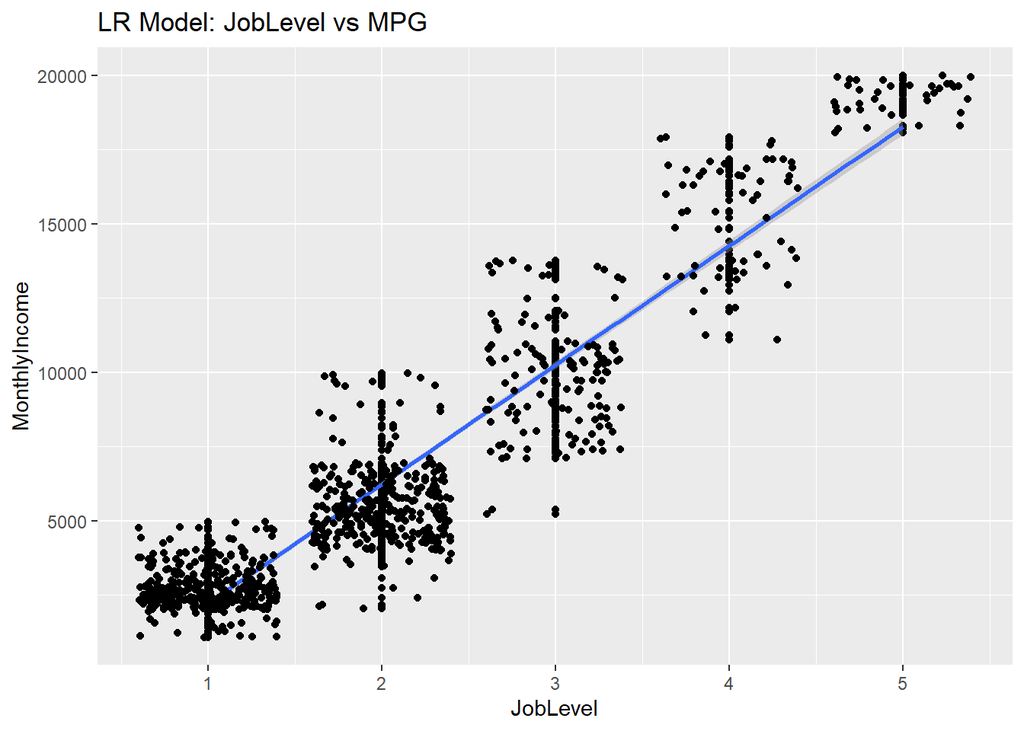

```r
# Plot
case %>%
  ggplot(aes(x = JobLevel, y = MonthlyIncome)) +
  geom_point() +
  geom_smooth(method = "lm") +
  geom_jitter() +
  ggtitle("LR Model: JobLevel vs MPG")
```

```r
# Perform linear regression
model <- lm(MonthlyIncome ~ JobLevel, data = na.omit(case))

# Extract p-value and confidence intervals
summary(model)
```

```
##
## Call:
## lm(formula = MonthlyIncome ~ JobLevel, data = na.omit(case))
##
## Residuals:
##     Min      1Q  Median      3Q     Max
## -5037.1  -928.2    80.1   697.1  3723.6
##
## Coefficients:
##             Estimate Std. Error t value Pr(>|t|)
## (Intercept) -1793.93     101.68  -17.64   <2e-16 ***
## JobLevel     4013.67      43.98   91.26   <2e-16 ***
## ---
## Signif. codes:  0 '***' 0.001 '**' 0.01 '*' 0.05 '.' 0.1 ' ' 1
##
## Residual standard error: 1413 on 868 degrees of freedom
## Multiple R-squared:  0.9056, Adjusted R-squared:  0.9055
## F-statistic:  8329 on 1 and 868 DF,  p-value: < 2.2e-16
```

```r
confint(model)
```

```
##                 2.5 %    97.5 %
## (Intercept) -1993.494 -1594.375
## JobLevel     3927.352  4099.990
```

```r
# Extract coefficients Manually
coefficients <- coef(model)
slope <- coefficients[2]
intercept <- coefficients[1]

# Print results
cat("Slope:", slope, "\n")
```

```
## Slope: 4013.671
```

```r
cat("MonthlyIncome = ", slope, "x +", intercept, "\n") # MonthlyIncome = 4013.671 x - 1793.934
```

```
## MonthlyIncome =  4013.671 x + -1793.934
```

Then, I ran a loop for the data set to obtain the pred_error_sq and eventually obtain the RMSE Calculating RMSE RMSE = 1414.96 Conclusion: RMSE < 3000 The RMSE was a favorable one at 1414.96. (Below the proposed $3000) Outside of this file, I took the No Salary csv, added a new column and pasted this formula to obtain the MonthlyIncome for each JobLevel in that data set = 4013.671 (JobLevel) - 1793.934

```r
# Model 1
pred_error_sq <- c(0)
for(i in 1:dim(case)[1]) {
 case_linear_train <- case[-i,]
  fit <- lm(MonthlyIncome ~ JobLevel,data = case_linear_train) # leave i'th observation out
  MonthlyIncome_i <- predict(fit, data.frame(JobLevel = case[i,16])) # predict i'th observation
  pred_error_sq <- pred_error_sq + (case[i,20] - MonthlyIncome_i)^2 # cumulate squared prediction errors
}

SSE = var(case$MonthlyIncome) * (869)

R_squared <- 1 - (pred_error_sq/SSE) # Measure for goodness of fit
R_squared
```

```
##         1
## 0.9051776
```

```r
MSE = pred_error_sq / 870
MSE
```

```
##       1
## 2002128
```

```r
RMSE = sqrt(pred_error_sq/870)
RMSE
```

```
##        1
## 1414.966
```